# Optimal Treatment Analysis

## Outcome Variable

**Outcome Variable:** whz

## Predictor Variables

**Intervention Variable:** fhtcm

**Adjustment Set:**

- arm
- W_mage
- W_fage
- meducyrs
- feducyrs
- W_mhtcm
- W_mwtkg
- W_mbmi
- single
- delta_W_mage
- delta_W_fage
- delta_meducyrs
- delta_feducyrs
- delta_W_mhtcm
- delta_W_mwtkg
- delta_W_mbmi
- delta_single

## Stratifying Variables

The analysis was stratified on these variable(s):

- agecat
- studyid
- country

## Data Summary

| agecat | studyid | country | fhtcm | n_cell | n |
| --- | --- | --- | --- | --- | --- |
| Birth | ki1000304b-SAS-CompFeed | INDIA | >=167 cm | 16 | 36 |
| Birth | ki1000304b-SAS-CompFeed | INDIA | <162 cm | 9 | 36 |
| Birth | ki1000304b-SAS-CompFeed | INDIA | [162-167) cm | 11 | 36 |
| Birth | ki1101329-Keneba | GAMBIA | >=167 cm | 710 | 1079 |
| Birth | ki1101329-Keneba | GAMBIA | <162 cm | 81 | 1079 |
| Birth | ki1101329-Keneba | GAMBIA | [162-167) cm | 288 | 1079 |
| Birth | ki1119695-PROBIT | BELARUS | >=167 cm | 5796 | 6208 |
| Birth | ki1119695-PROBIT | BELARUS | <162 cm | 83 | 6208 |
| Birth | ki1119695-PROBIT | BELARUS | [162-167) cm | 329 | 6208 |
| Birth | ki1135781-COHORTS | GUATEMALA | >=167 cm | 10 | 86 |
| Birth | ki1135781-COHORTS | GUATEMALA | <162 cm | 44 | 86 |
| Birth | ki1135781-COHORTS | GUATEMALA | [162-167) cm | 32 | 86 |
| 6 months | ki1000304b-SAS-CompFeed | INDIA | >=167 cm | 98 | 219 |
| 6 months | ki1000304b-SAS-CompFeed | INDIA | <162 cm | 51 | 219 |
| 6 months | ki1000304b-SAS-CompFeed | INDIA | [162-167) cm | 70 | 219 |
| 6 months | ki1000304b-SAS-FoodSuppl | INDIA | >=167 cm | 21 | 94 |
| 6 months | ki1000304b-SAS-FoodSuppl | INDIA | <162 cm | 34 | 94 |
| 6 months | ki1000304b-SAS-FoodSuppl | INDIA | [162-167) cm | 39 | 94 |
| 6 months | ki1101329-Keneba | GAMBIA | >=167 cm | 979 | 1510 |
| 6 months | ki1101329-Keneba | GAMBIA | <162 cm | 113 | 1510 |
| 6 months | ki1101329-Keneba | GAMBIA | [162-167) cm | 418 | 1510 |
| 6 months | ki1119695-PROBIT | BELARUS | >=167 cm | 5615 | 6014 |
| 6 months | ki1119695-PROBIT | BELARUS | <162 cm | 80 | 6014 |
| 6 months | ki1119695-PROBIT | BELARUS | [162-167) cm | 319 | 6014 |
| 6 months | ki1135781-COHORTS | GUATEMALA | >=167 cm | 19 | 151 |
| 6 months | ki1135781-COHORTS | GUATEMALA | <162 cm | 83 | 151 |
| 6 months | ki1135781-COHORTS | GUATEMALA | [162-167) cm | 49 | 151 |
| 24 months | ki1101329-Keneba | GAMBIA | >=167 cm | 823 | 1298 |
| 24 months | ki1101329-Keneba | GAMBIA | <162 cm | 96 | 1298 |
| 24 months | ki1101329-Keneba | GAMBIA | [162-167) cm | 379 | 1298 |
| 24 months | ki1119695-PROBIT | BELARUS | >=167 cm | 1409 | 1496 |
| 24 months | ki1119695-PROBIT | BELARUS | <162 cm | 21 | 1496 |
| 24 months | ki1119695-PROBIT | BELARUS | [162-167) cm | 66 | 1496 |
| 24 months | ki1135781-COHORTS | GUATEMALA | >=167 cm | 28 | 242 |
| 24 months | ki1135781-COHORTS | GUATEMALA | <162 cm | 132 | 242 |
| 24 months | ki1135781-COHORTS | GUATEMALA | [162-167) cm | 82 | 242 |

The following strata were considered:

- agecat: 24 months, studyid: ki1101329-Keneba, country: GAMBIA
- agecat: 24 months, studyid: ki1119695-PROBIT, country: BELARUS
- agecat: 24 months, studyid: ki1135781-COHORTS, country: GUATEMALA
- agecat: 6 months, studyid: ki1000304b-SAS-CompFeed, country: INDIA
- agecat: 6 months, studyid: ki1000304b-SAS-FoodSuppl, country: INDIA
- agecat: 6 months, studyid: ki1101329-Keneba, country: GAMBIA
- agecat: 6 months, studyid: ki1119695-PROBIT, country: BELARUS
- agecat: 6 months, studyid: ki1135781-COHORTS, country: GUATEMALA
- agecat: Birth, studyid: ki1000304b-SAS-CompFeed, country: INDIA
- agecat: Birth, studyid: ki1101329-Keneba, country: GAMBIA
- agecat: Birth, studyid: ki1119695-PROBIT, country: BELARUS
- agecat: Birth, studyid: ki1135781-COHORTS, country: GUATEMALA

## Methods Detail

We’re interested in the causal parameters $E[Y_a]$ for all values of $a \in \mathcal{A}$. These parameters represent the mean outcome if, possibly contrary to fact, we intervened to set all units to have $A=a$. Under the randomization and positivity assumptions, these are identified by the statistical parameters $\psi_a=E_W[E_{Y|A,W}(Y|A=a,W)]$. In addition, we’re interested in the mean of $Y$, $E[Y]$ under no intervention (the observed mean). We will estimate these parameters by using SuperLearner to fit the relevant likelihood factors – $E_{Y|A,W}(Y|A=a,W)$ and $p(A=a|W)$, and then updating our likelihood fit using a joint TMLE.

For unadjusted analyses ($W=\{\}$), initial likelihoods were estimated using Lrnr_glm to estimate the simple $E(Y|A)$ and Lrnr_mean to estimate $p(A)$. For adjusted analyses, a small library containing Lrnr_glmnet, Lrnr_xgboost, and Lrnr_mean was used.

Having estimated these parameters, we will then use the delta method to estimate relative risks and attributable risks relative to a prespecified baseline level of $A$.

# Results Detail

## Results Plots

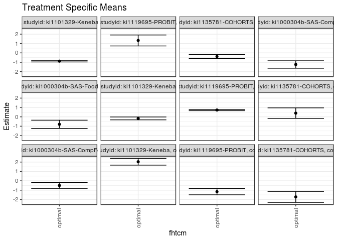

## Results Table

### Parameter: TSM

| agecat | studyid | country | intervention_level | baseline_level | estimate | ci_lower | ci_upper |
| --- | --- | --- | --- | --- | --- | --- | --- |
| Birth | ki1000304b-SAS-CompFeed | INDIA | optimal | observed | -0.5003725 | -0.8072047 | -0.1935403 |
| Birth | ki1101329-Keneba | GAMBIA | optimal | observed | 2.0331089 | 1.6736599 | 2.3925579 |
| Birth | ki1119695-PROBIT | BELARUS | optimal | observed | -1.1619828 | -1.4923273 | -0.8316384 |
| Birth | ki1135781-COHORTS | GUATEMALA | optimal | observed | -1.7162457 | -2.3032960 | -1.1291953 |
| 6 months | ki1000304b-SAS-CompFeed | INDIA | optimal | observed | -1.2415538 | -1.6392933 | -0.8438142 |
| 6 months | ki1000304b-SAS-FoodSuppl | INDIA | optimal | observed | -0.7953908 | -1.2330555 | -0.3577262 |
| 6 months | ki1101329-Keneba | GAMBIA | optimal | observed | -0.1673470 | -0.3217238 | -0.0129703 |
| 6 months | ki1119695-PROBIT | BELARUS | optimal | observed | 0.7281974 | 0.6594972 | 0.7968976 |
| 6 months | ki1135781-COHORTS | GUATEMALA | optimal | observed | 0.3949046 | -0.1679870 | 0.9577963 |
| 24 months | ki1101329-Keneba | GAMBIA | optimal | observed | -0.8791784 | -0.9684968 | -0.7898599 |
| 24 months | ki1119695-PROBIT | BELARUS | optimal | observed | 1.3262415 | 0.7419259 | 1.9105570 |
| 24 months | ki1135781-COHORTS | GUATEMALA | optimal | observed | -0.3861072 | -0.6034658 | -0.1687486 |

### Parameter: E(Y)

| agecat | studyid | country | intervention_level | baseline_level | estimate | ci_lower | ci_upper |
| --- | --- | --- | --- | --- | --- | --- | --- |
| Birth | ki1000304b-SAS-CompFeed | INDIA | observed | observed | -0.3272222 | -0.8589108 | 0.2044664 |
| Birth | ki1101329-Keneba | GAMBIA | observed | observed | 1.7064875 | 1.6129215 | 1.8000534 |
| Birth | ki1119695-PROBIT | BELARUS | observed | observed | -1.1869878 | -1.5196648 | -0.8543107 |
| Birth | ki1135781-COHORTS | GUATEMALA | observed | observed | -0.9645349 | -1.2747161 | -0.6543537 |
| 6 months | ki1000304b-SAS-CompFeed | INDIA | observed | observed | -0.9419178 | -1.1969133 | -0.6869223 |
| 6 months | ki1000304b-SAS-FoodSuppl | INDIA | observed | observed | -1.1186170 | -1.3500089 | -0.8872251 |
| 6 months | ki1101329-Keneba | GAMBIA | observed | observed | -0.2272250 | -0.2854487 | -0.1690012 |
| 6 months | ki1119695-PROBIT | BELARUS | observed | observed | 0.5781244 | 0.5049068 | 0.6513420 |
| 6 months | ki1135781-COHORTS | GUATEMALA | observed | observed | -0.1388742 | -0.3337686 | 0.0560202 |
| 24 months | ki1101329-Keneba | GAMBIA | observed | observed | -0.7963776 | -0.8498028 | -0.7429525 |
| 24 months | ki1119695-PROBIT | BELARUS | observed | observed | 0.8158478 | 0.6746021 | 0.9570935 |
| 24 months | ki1135781-COHORTS | GUATEMALA | observed | observed | -0.5800000 | -0.6966670 | -0.4633330 |

### Parameter: PAR

| agecat | studyid | country | intervention_level | baseline_level | estimate | ci_lower | ci_upper |
| --- | --- | --- | --- | --- | --- | --- | --- |
| Birth | ki1000304b-SAS-CompFeed | INDIA | optimal | observed | 0.1731503 | -0.4550695 | 0.8013701 |
| Birth | ki1101329-Keneba | GAMBIA | optimal | observed | -0.3266214 | -0.6716257 | 0.0183829 |
| Birth | ki1119695-PROBIT | BELARUS | optimal | observed | -0.0250049 | -0.1531703 | 0.1031605 |
| Birth | ki1135781-COHORTS | GUATEMALA | optimal | observed | 0.7517108 | 0.1958392 | 1.3075824 |
| 6 months | ki1000304b-SAS-CompFeed | INDIA | optimal | observed | 0.2996360 | -0.1332821 | 0.7325540 |
| 6 months | ki1000304b-SAS-FoodSuppl | INDIA | optimal | observed | -0.3232262 | -0.7200944 | 0.0736420 |
| 6 months | ki1101329-Keneba | GAMBIA | optimal | observed | -0.0598779 | -0.2018402 | 0.0820843 |
| 6 months | ki1119695-PROBIT | BELARUS | optimal | observed | -0.1500730 | -0.2232353 | -0.0769108 |
| 6 months | ki1135781-COHORTS | GUATEMALA | optimal | observed | -0.5337788 | -1.0498460 | -0.0177116 |
| 24 months | ki1101329-Keneba | GAMBIA | optimal | observed | 0.0828007 | 0.0031490 | 0.1624525 |
| 24 months | ki1119695-PROBIT | BELARUS | optimal | observed | -0.5103937 | -1.0116417 | -0.0091456 |
| 24 months | ki1135781-COHORTS | GUATEMALA | optimal | observed | -0.1938928 | -0.3893992 | 0.0016137 |